# Data screening and transformations

Last Updated 2018-08-03 23:05:19

# Data screening and transformations (*PMA5 Ch 3 and 4*)

Recall the aim of data preparation, screening, wrangling, or transforming is to

- Identify outliers and inconsistent values
- Assess normality of the distribution
- Explore data transformations to aid description, inference.

## Load data

Load in your cleaned depression data set.

```r
depress <- read.table("https://norcalbiostat.netlify.com/data/depress_081217.txt",
                      sep="\t", header=TRUE)
```

## Describe the distribution of income

Be sure to write out your description in paragraph form and discuss the location (measures of center), spread (measures of variance) and shape (normality or skewness) of the distribution using an appropriate plot and summary statistics as evidence. Connect your text to specific features of the plot and/or summary statistics, do not just say “as you can see in the plot…”. Make sure the plot is fully annotated with an appropriate title and axes labels.

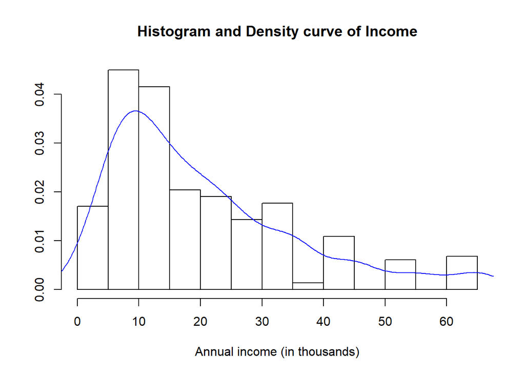

```r
hist(depress$income, prob=TRUE, xlab="Annual income (in thousands)",
     main="Histogram and Density curve of Income", ylab="")
lines(density(depress$income), col="blue")
```

```r
summary(depress$income)
```

```
##    Min. 1st Qu.  Median    Mean 3rd Qu.    Max.
##    2.00    9.00   15.00   20.57   28.00   65.00
```

In general, transformations are more effective when the the standard deviation is large relative to the mean. One rule of thumb is if the sd/mean ratio is less than 1/4, a transformation may not be necessary.

```r
sd(depress$income) / mean(depress$income)
```

```
## [1] 0.743147
```

```r
max(depress$income) / (min(depress$income)+.1)
```

```
## [1] 30.95238
```

Note these rules are not meaningful for data without a natural zero. The book goes into more detail about options for interval data.

## Assessing Normality

Another common method of assessing normality is to create a normal probability (or normal quantile) plot.

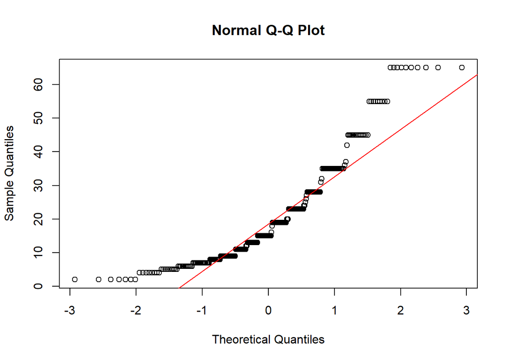

```r
qqnorm(depress$income);qqline(depress$income, col="red")
```

The points on the normal probability plot do not follow the red reference line very well. The dots show a more curved, or `U` shaped form rather than following a linear line. This is another indication that the data is skewed and a transformation for normality should be created.

# Transformations

## Taking logs

```r
log10inc <- log10(depress$income)
loginc   <- log(depress$income)
xincome  <- -1/(depress$income)^(-1/3)
```

Create a single plot that display normal probability plots for the original, and each of the three transformations of income. Here I use the base graphics grid organizer `par(mfrow=c(r,c))` where `r` is the number of rows and `c` is the number of columns to show these plots side by side.

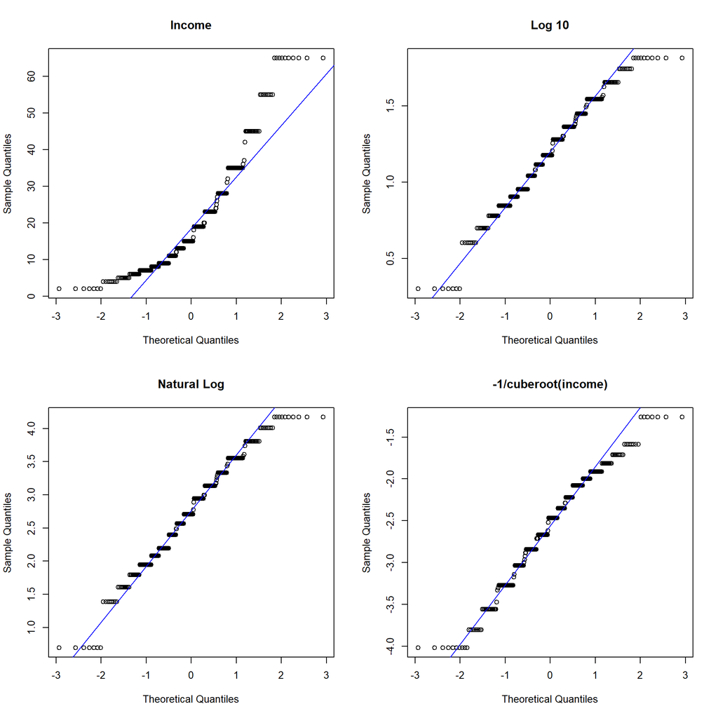

```r
par(mfrow=c(2,2)) # Try (4,1) and (1,4) to see how this works.
qqnorm(depress$income, main="Income"); qqline(depress$income,col="blue")
qqnorm(log10inc, main="Log 10"); qqline(log10inc, col="blue")
qqnorm(loginc, main = "Natural Log"); qqline(loginc, col="blue")
qqnorm(xincome, main="-1/cuberoot(income)"); qqline(xincome, col="blue")
```

Which transformation does a better job of normalizing the distribution of Income?

## logs of zero values

Take the logarithm of the CESD score plus 1 and compare the histograms of CESD and log(CESD+1). Describe the distribution of each.

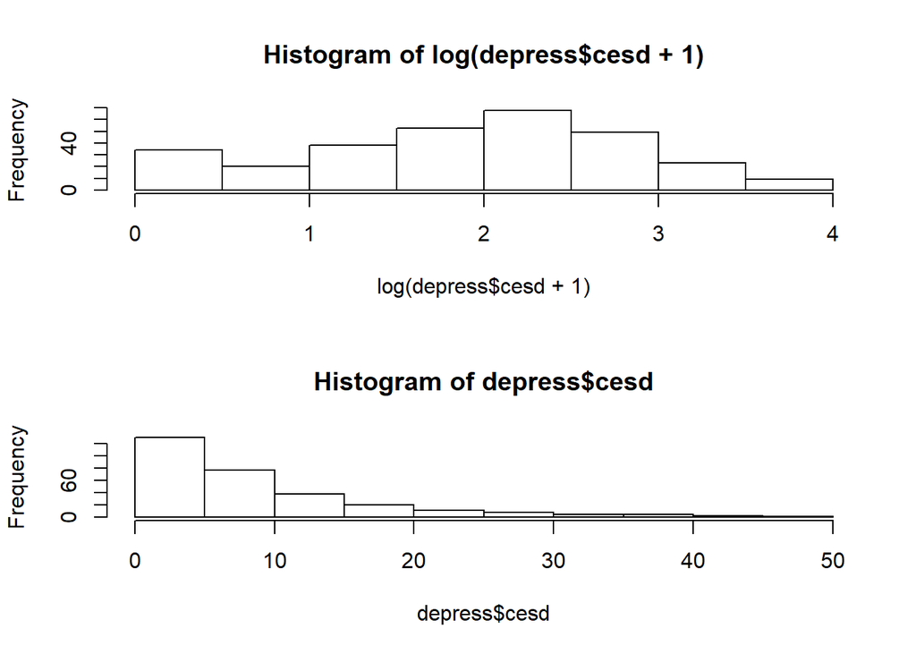

```r
par(mfrow=c(2,1))
hist(log(depress$cesd+1))
hist(depress$cesd)
```

Question: Why was the +1 added to CESD prior to taking the log?

Consider the variable `AGESMOKE`. This represents the age in years when the respondent started smoking. If the respondent did not start smoking, `AGESMOKE` was assigned to a value of zero.

Question: Would we need to recode this variable during our data preparation stage? Why or why not?

# Session Info